# Consumo de cerveja

Stella Trajano

20/04/2021

Quantos litros de cerveja em média são consumidos em um fim de semana? Faça chuva ou faça sol, a gelada se faz igualmente presente? Temperatura subiu, um litrão cai bem? As respostas para tais questionamentos vão ser deduzidas através de uma base de dados com 365 observações sobre temperatura, precipitação e consumo de cerveja.

### Processo de carregamento de dados e pacotes

```r
library(dplyr)
library(car)
library(rstatix)
library(emmeans)
library(ggplot2)
library(knitr)
library(kableExtra)
library(htmltools)
library(lubridate)
```

- Importando a base de dados e recodificando a variável Final de semana

```r
dados <- read.csv2('consumo_cerveja.csv')
dados$Final.de.Semana <- factor(dados$Final.de.Semana,
                                levels = c(0,1),
                                labels = c("Dia de semana", "Fim de Semana"))
```

- Criando uma tabela mais organizada dos dados

```r
kableExtra::kable(head(dados, 10), col.names = c("Data","Temperatura média", "Temperatura mínima", "Temperatura máxima", "Precipitação","Final de semana","Consumo de cerveja")) %>%
  kableExtra::kable_styling(full_width = F, bootstrap_options = c("striped", "hover", "condensed", "responsive"))
```

| Data | Temperatura média | Temperatura mínima | Temperatura máxima | Precipitação | Final de semana | Consumo de cerveja |
| --- | --- | --- | --- | --- | --- | --- |
| 01/01/2019 | 27.30 | 23.9 | 32.5 | 0.0 | Dia de semana | 25461 |
| 02/01/2019 | 27.02 | 24.5 | 33.5 | 0.0 | Dia de semana | 28972 |
| 03/01/2019 | 24.82 | 22.4 | 29.9 | 0.0 | Fim de Semana | 30814 |
| 04/01/2019 | 23.98 | 21.5 | 28.6 | 1.2 | Fim de Semana | 29799 |
| 05/01/2019 | 23.82 | 21.0 | 28.3 | 0.0 | Dia de semana | 28900 |
| 06/01/2019 | 23.78 | 20.1 | 30.5 | 12.2 | Dia de semana | 28218 |
| 07/01/2019 | 24.00 | 19.5 | 33.7 | 0.0 | Dia de semana | 29732 |
| 08/01/2019 | 24.90 | 19.5 | 32.8 | 48.6 | Dia de semana | 28397 |
| 09/01/2019 | 28.20 | 21.9 | 34.0 | 4.4 | Dia de semana | 24886 |
| 10/01/2019 | 26.76 | 22.1 | 34.2 | 0.0 | Fim de Semana | 37937 |

### Descrição dos dados

O banco contém 365 observações, as quais são referentes aos dias em que foram anotados o consumo de cerveja por litro durante 1 ano, sendo 104 dessas obeservações, fins de semana.

- Calculando as estatísticas do banco de dados

```r
mean(dados$Consumo.de.cerveja..litros.)
```

```
## [1] 25401.37
```

```r
summary(dados$Temperatura.Media..C.)
```

```
##    Min. 1st Qu.  Median    Mean 3rd Qu.    Max.    NA's
##   12.90   19.00   21.37   21.29   23.29   52.86       1
```

```r
mean(dados$Precipitacao..mm.)
```

```
## [1] 5.196712
```

- Gerando gráfico de dispersão

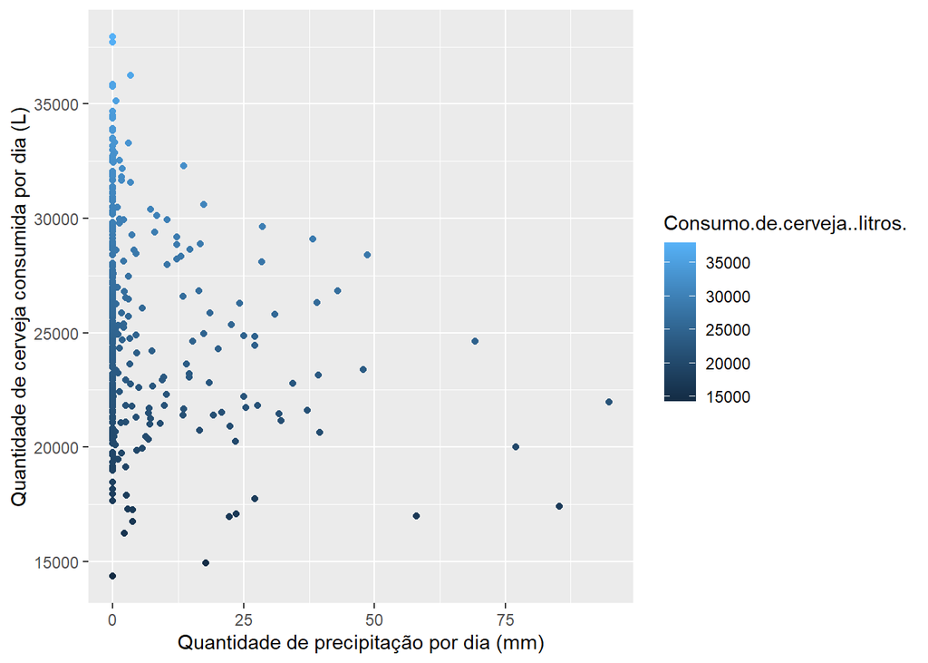

```r
ggplot(dados,
       aes(x = Precipitacao..mm., y = Consumo.de.cerveja..litros., color = Consumo.de.cerveja..litros.)) +
  geom_point() +
  xlab("Quantidade de precipitação por dia (mm)") +
  ylab("Quantidade de cerveja consumida por dia (L)")
```

- Tabela mostrando média de consumo de cerveja por dia

```r
ConsumoPorDia <- dados %>%
  group_by(Final.de.Semana)%>% summarise(
    mean(Consumo.de.cerveja..litros., na.rm = T))

kable(ConsumoPorDia, col.names = c("Dia","Consumo médio de cerveja")) %>%
  kable_styling(full_width = F, bootstrap_options = c("striped", "hover", "condensed", "responsive"))
```

| Dia | Consumo médio de cerveja |
| --- | --- |
| Dia de semana | 23998.22 |
| Fim de Semana | 28922.72 |

A tabela mostra que existe um aumento considerável (por volta de 5 mil litros) de consumo de cerveja nos fins de semana.O que pode ser melhor obeservado através do gráfico a seguir:

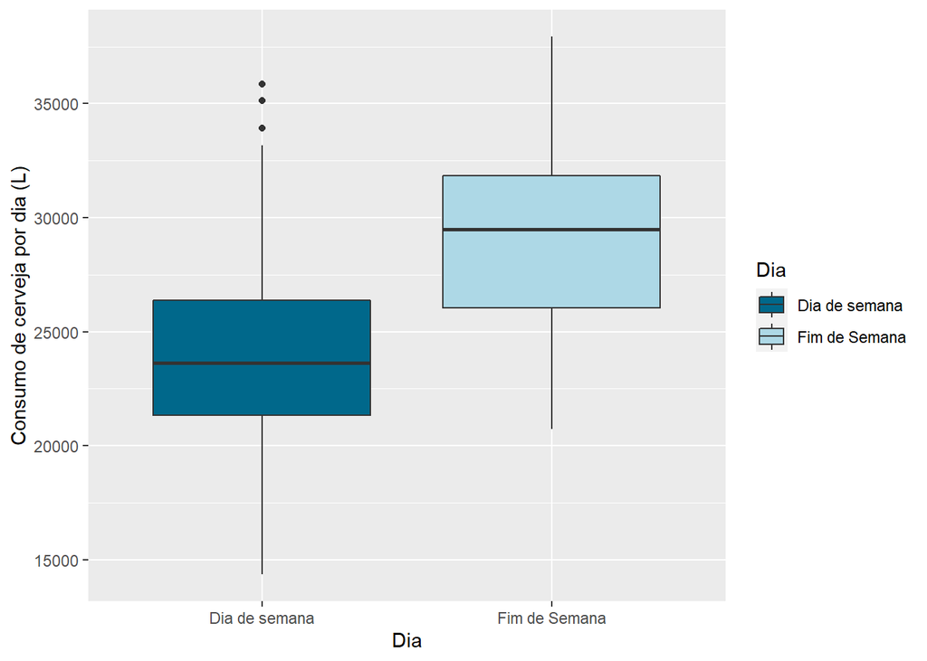

```r
ggplot(dados, aes(x = Final.de.Semana, y = Consumo.de.cerveja..litros., fill = Final.de.Semana)) +
  geom_boxplot() +
  xlab("Dia") +
  ylab("Consumo de cerveja por dia (L)") +
  scale_fill_manual("Dia",values=c("deepskyblue4","lightblue"))
```

O bloxplot confirma o maior consumo de cerveja aos fins de semana. É notável três dias de semana em que as pessoas consumiram muito além do comum, o que pode indicar a presença de feriados.

- Código para mudar o formato da variável data que se encontrava como character para formato de dia, mês e ano.

```r
dados$Data = dmy(paste(dados$Data))
```

- Agrupando variável “Temperatura média” por “Data”, separando em grupos de quatro estações.

```r
TemperaturaAoAno <- dados %>%
  group_by(Data)%>% summarise(
    mean(Temperatura.Media..C., na.rm = T))

estacao1 <- TemperaturaAoAno[TemperaturaAoAno$Data >= "2019-01-01" & TemperaturaAoAno$Data <= "2019-02-28",]

estacao1 <- rbind(estacao1,TemperaturaAoAno[TemperaturaAoAno$Data >= "2019-12-01" & TemperaturaAoAno$Data <= "2019-12-31",])

estacao2 <- TemperaturaAoAno[TemperaturaAoAno$Data >= "2019-03-01" & TemperaturaAoAno$Data <= "2019-05-31",]

estacao2[is.na(estacao2)] <- 0

estacao3 <- TemperaturaAoAno[TemperaturaAoAno$Data >= "2019-06-01" & TemperaturaAoAno$Data <= "2019-08-30",]

estacao4 <- TemperaturaAoAno[TemperaturaAoAno$Data >= "2019-09-01" & TemperaturaAoAno$Data <= "2019-11-30",]
```

- Criando uma tabela com a temperatura média por dia para cada estação

```r
estacoes <- data.frame(
  c("Estação 1", "Estação 2", "Estação 3", "Estação 4"),

  c(mean(estacao1$`mean(Temperatura.Media..C., na.rm = T)`), mean(estacao2$`mean(Temperatura.Media..C., na.rm = T)`), mean(estacao3$`mean(Temperatura.Media..C., na.rm = T)`), mean(estacao4$`mean(Temperatura.Media..C., na.rm = T)`))
)

kable(estacoes, col.names = c("Estação","Temperatura Média")) %>%
  kableExtra::kable_styling(full_width = F, bootstrap_options = c("striped", "hover", "condensed", "responsive"))
```

| Estação | Temperatura Média |
| --- | --- |
| Estação 1 | 24.38222 |
| Estação 2 | 20.29370 |
| Estação 3 | 18.56000 |
| Estação 4 | 21.70242 |

A tabela nos apresenta a estação 1 com maior média de temperatura por dia, diferente da estação 3, a qual nos traz a menor temperatura média apresentada (18.56ºC). Sendo assim, iremos denomina-las, respectivamente, de verão e inverno. A seguir, será feita a análise sobre em qual das duas estações há maior consumo de cerveja.

- Criando dataframe com coluna recodificada por nome da estação

```r
ConsumoEstacao <- dados %>%
  group_by(Data)%>% summarise(
    mean(Consumo.de.cerveja..litros., na.rm = T))

verao <- ConsumoEstacao[ConsumoEstacao$Data >= "2019-01-01" & ConsumoEstacao$Data <= "2019-02-28",]

verao <- rbind(verao,ConsumoEstacao[ConsumoEstacao$Data >= "2019-12-01" & ConsumoEstacao$Data <= "2019-12-31",])

verao$Data = "verão"

inverno <-ConsumoEstacao[ConsumoEstacao$Data >= "2019-06-01" & ConsumoEstacao$Data <= "2019-08-30",]

inverno$Data = "inverno"
```

- Criando tabela com para explicitar a diferença do consumo de cervejas no verão e inverno

```r
Consumo_estacao <- data.frame(
  c("Verão","Inverno"),
  c(mean(verao$`mean(Consumo.de.cerveja..litros., na.rm = T)`), mean(inverno$`mean(Consumo.de.cerveja..litros., na.rm = T)`))
)
kable(Consumo_estacao, col.names = c("Estação","Consumo médio")) %>%
  kableExtra::kable_styling(full_width = F, bootstrap_options = c("striped", "hover", "condensed", "responsive"))
```

| Estação | Consumo médio |
| --- | --- |
| Verão | 27223.44 |
| Inverno | 23992.40 |